# 2017-01-30

2017-02-12

## Today's topics

- Pregistration and registered reports
  - What, why, who, how?
- Introduction to [RStudio](http://rstudio.com)
- Introduction to R Markdown

## Registered reports

- What are they?
- Why are they a thing?
- Who's doing them?
- How they work and how to get involved

## What are they?

- Peer review and provisional acceptance of methodologically sound study proposals

## Why registered reports?

- Results (positive or null) don't determine publication (prevent publication bias)
- Reduce questionable practices
  - p-hacking
  - HARKing

## Why [**not**](http://www.cogsci.nl/blog/miscellaneous/215-the-pros-and-cons-of-pre-registration-in-fundamental-research) registered reports

- Restrict creativity in reporting "un-registered"/exploratory analyses?
  - Clearer communication about confirmatory vs. exploratory
- Mandatory vs. optional
- Clinical trials vs. fundamental research
- Exploration is not a dirty word

## Who's doing them?

- [Journals with Registered Reports](https://cos.io/rr/#journals) from COS
- [*Cognition & Emotion*](http://explore.tandfonline.com/page/beh/pcem-registered-reports-of-replication-studies/)
- [*Cortex*](http://cdn.elsevier.com/promis_misc/PROMIS%20pub_idt_CORTEX%20Guidelines_RR_29_04_2013.pdf)
- [*Nature Human Behavior*](http://www.nature.com/nathumbehav/about/content)

## How do they work

- Google sheet comparing features https://docs.google.com/spreadsheets/d/1D4_k-8C_UENTRtbPzXfhjEyu3BfLxdOsn9j-otrO870/edit#gid=0

[figure not shown]

## Preregistration separate from publication

[video not shown]

## [AsPredicted.org](https://aspredicted.org/)

- Standardized preregistration tool
- Separate confirmatory from exploratory analyses
- One author completes checklist, others receive email to approve
- Unique (private) URL to pdf
- Share when you like or never

## Your thoughts on preregistration, registered reports?

## Tools for reproducible workflows

## [RStudio](http://rstudio.com)

- An integrated development environment (IDE) for R

## Components of RStudio

- Code editor
- R console
- Integrated help
- Image viewer
- Integration with git and other version-control packages
- Project management

## RStudio in the cloud

- RStudio can be run in a browser from a server running RStudio Server
- [Demo](http://ec2-52-90-103-156.compute-1.amazonaws.com/)
  - Running this under Amazon Web Services (AWS) free tier
- Instructions for doing this yourself can be found [here](http://strimas.com/r/rstudio-cloud-1/)

## R Markdown

- [Markdown](https://daringfireball.net/projects/markdown/)
  - Mark-up language to make it easy to write HTML
- R Markdown special type of Markdown
  - Allows for "literate" programming, mixing text, analysis, figures
  - Adds to Markdown syntax

## [Markdown](https://daringfireball.net/projects/markdown) syntax

- Text formatting
  - *italics* by surrounding text with single asterisks or underscores: `*italics*` or `_italics_`
  - **boldface** by surrounding text with double asterisks or underscores: `**boldface**` or `__boldface__`
  - strikethrough by surrounding text with double tildes: `~~strikethrough~~`
  - [Clickable URLs](http://www.psu.edu) by surrounding link text with square brackets and URL with parentheses: `[Clickable URLs](http://www.psu.edu)`

## Markdown syntax

- Paragraph formatting
  - Headings with level specified by the number of hash (#) marks
  - Lists (bullet and enumerated)
  - Block quotes
  - Code blocks

```
# This is a Heading 1
## This is a Heading 2
### This is a Heading 3
```

- An item
  - A nested item
    - A doubly-nested item
- Another item

Code:

```
- An item
    - A nested item
        - A doubly-nested item
- Another item
```

1. An enumerated item
   - A nested item
2. A second enumerated item

Code:

```
1. An enumerated item
    - A nested item
1. A second enumerated item
```

Notice how the numbers are incremented automatically!

> Four score and seven years ago, some famous President spoke infamous words that would live on throughout history. These words are famous enough that I want to highlight them with a block quote.

```
> Four score and seven years ago, some famous President
> spoke infamous words that would live on throughout history.
> These words are famous enough that I want to highlight them with a block quote.
```

## More on Markdown syntax

- Images can be inserted using this syntax `![Alt text](/path/to/img.jpg)`
- Comments – won't print in rendered output – `<!- This is a comment ->`

## R Markdown additions

- .Rmd extension
- Combine text, code, images, figures, video
- "Computable" reports, documents, slide shows, notebooks
- Output in multiple formats from the same file

## Make some data

```r
x = rnorm(n = 100, mean = 0, sd = 1)   # N(0,1)
y = rnorm(n = 100, mean = 2, sd = 0.5) # N(2, 0.5)
```

## Summary of x, y

```r
summary(x)
```

```
##    Min. 1st Qu.  Median    Mean 3rd Qu.    Max.
## -2.8360 -0.7226 -0.1425 -0.1681  0.3255  1.8180
```

```r
summary(y)
```

```
##    Min. 1st Qu.  Median    Mean 3rd Qu.    Max.
##  0.8747  1.7270  2.0370  2.0030  2.3650  3.0380
```

## Histogram of x

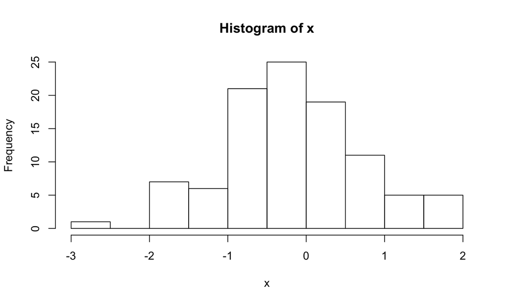

```r
hist(x)
```

## Histogram of y

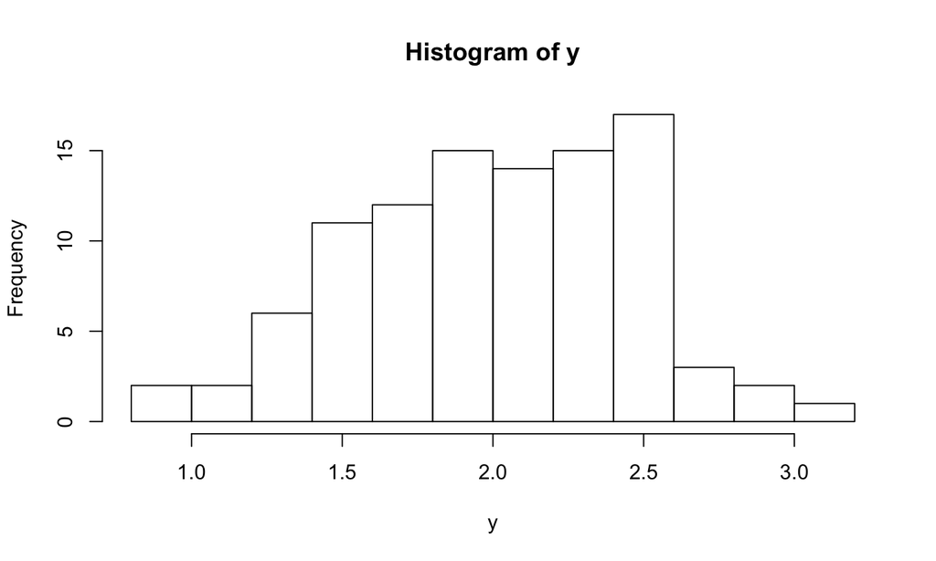

```r
hist(y)
```

## Embed figure saved locally using HTML

`<img src="../img/my-img.jpg" height=500px>`

Height parameter (or, e.g. `width=800px`) is optional, but useful. Remember Markdown -> HTML.

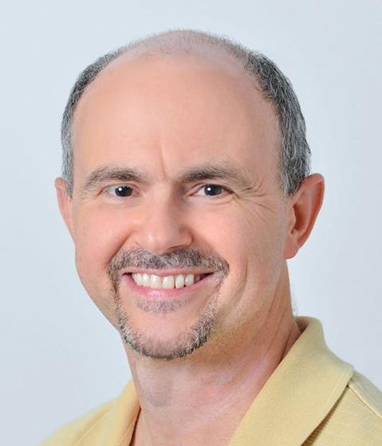

## Embed figure from the web

`<img src="http://cdn.abclocal.go.com/content/wpvi/images/cms/280434_1280x720.jpg" width=900px>`

[figure not shown]

## Embed YouTube video

`<iframe width="420" height="315" src="https://www.youtube.com/embed/9hUy9ePyo6Q" frameborder="0" allowfullscreen></iframe>`

- YouTube gives you code to cut and paste.

[video not shown]

## Printing computed variables

```r
summ.x = summary(x)
summ.y = summary(y)
names(summ.x) # Figure out variable names for indexing
```

```
## [1] "Min."    "1st Qu." "Median"  "Mean"    "3rd Qu." "Max."
```

*Index by variable name:* X lies within the range of [-2.836, 1.818].

*Index by numeric index:* The (y-x) difference in means is `2.1711`.

*Calculate and report:* The correlation between x and y is -0.0520936.